# Satellite Image Classification using Deep Neural Network with Keras in R with GPU Support (Windows 10)

Zia Ahmed, PhD, University at Buffalo

April 5, 2018

This tutorial will show how to implement [Deep Neural Network](https://en.wikipedia.org/wiki/Deep_learning) for [pixel based](https://gis.stackexchange.com/questions/237461/distinction-between-pixel-based-and-object-based-classification) [supervised classification](https://articles.extension.org/pages/40214/whats-the-difference-between-a-supervised-and-unsupervised-image-classification) of [Sentinel-2 multispectral images](https://sentinel.esa.int/web/sentinel/missions/sentinel-2) using [keras](https://keras.rstudio.com/) package in [R](https://cloud.r-project.org/) under [Windows 10](https://www.microsoft.com/en-us/software-download/windows10).

[keras](https://keras.rstudio.com/) is a popular Python package for deep neural networks with multiple backends, including [TensorFlow](https://www.tensorflow.org/), [Microsoft Cognitive Toolkit (CNTK)](https://docs.microsoft.com/en-us/cognitive-toolkit/), and [Theano](http://deeplearning.net/software/theano/). Two R packages allow you to use [Keras[(https://keras.rstudio.com/)] from R: [keras](https://keras.rstudio.com/) and kerasR. The keras package is able to provide a flexible and feature-rich API and can run both [CPU and GUP version of TensorFlow](https://www.tensorflow.org/install/install_windows) in both Windows and Linux. If you want to run this tutorial with [GUP version of TensorFlow](https://www.tensorflow.org/install/install_windows) you need following prerequisites in your system:

*[NVIDIA GUP](https://developer.nvidia.com/cuda-gpus): First, you must make sure weather your computer is running with [NVIDIAÂ® GPU](https://developer.nvidia.com/cuda-gpus) or not. Follow the instruction as described [here](http://nvidia.custhelp.com/app/answers/detail/a_id/2040/~/identifying-the-graphics-card-model-and-device-id-in-a-pc).

*[CUDA Toolkit v9.0](https://developer.nvidia.com/cuda-90-download-archive?target_os=Windows&target_arch=x86_64&target_version=10&target_type=exelocal): If you have an NVIDIAÂ® GPU in your system, you need to download and install [CUDA Toolkit v9.0](https://developer.nvidia.com/cuda-90-download-archive?target_os=Windows&target_arch=x86_64&target_version=10&target_type=exelocal). Detail installation steps can be found [here](http://nvidia.custhelp.com/app/answers/detail/a_id/2040/~/identifying-the-graphics-card-model-and-device-id-in-a-pc).

*[cuDNN v7.0](https://developer.nvidia.com/cudnn): The download the zip file version [cuDNN v7.0](https://developer.nvidia.com/cudnn) for your CUDA Toolkit v9.0.You need to extract the zip file and add the location where you extracted it to your system PATH. Detail installation steps can be found here here.

Detail installation steps of Keras backend GPU or CUP version of Tensorflow can be found [here](https://tensorflow.rstudio.com/keras/reference/install_keras.html).

```r
start_time <- Sys.time()
```

#### Import packages

```r
library(rgdal)
library(raster)
library(dplyr)
library(RStoolbox)
library(plyr)
library(keras)
library(tfruns)
library(tfestimators)
```

#### Setworking directory

```r
setwd("F:\\My_GitHub\\DNN_keras_R")
```

#### Load data

```r
point<-read.csv("point_data.csv", header=T)
grid<-read.csv("grid_data.csv",header=T)
```

#### Create a data frame and clean the data

```r
point.df<-cbind(point[c(4:13)],Class_ID=point$Class)
grid.df<-cbind(grid[c(4:13)])
grid.xy<-grid[c(3,1:2)]
```

#### Convert Class to dummy variables

```r
point.df[,11] <- as.numeric(point.df[,11]) -1
```

#### Convert data as matrix

```r
point.df<- as.matrix(point.df)
grid.df <- as.matrix(grid.df)
```

#### Set `dimnames` to `NULL`

```r
dimnames(point.df) <- NULL
dimnames(grid.df) <- NULL
```

#### Standardize_the data: ((x-mean(x))/sd(x))

```r
point.df[, 1:10] = scale(point.df[, 1:10])
grid.df[, 1:10] = scale(grid.df[, 1:10])
```

### Split data

```r
##  Determine sample size
ind <- sample(2, nrow(point.df), replace=TRUE, prob=c(0.80, 0.20))
# Split the `Split data
training <- point.df[ind==1, 1:10]
test <- point.df[ind==2, 1:10]
# Split the class attribute
trainingtarget <- point.df[ind==1, 11]
testtarget <- point.df[ind==2, 11]
```

#### Hyperparameter flag

```r
FLAGS <- flags(
  flag_numeric('dropout_1', 0.2, 'First dropout'),
  flag_numeric('dropout_2', 0.2, 'Second dropout'),
  flag_numeric('dropout_3', 0.1, 'Third dropout'),
  flag_numeric('dropout_4', 0.1, 'Forth dropout')
  )
```

### Define model parameters with 4 hidden layers with 200 neuron

```r
model <- keras_model_sequential()
model %>%
  # Imput layer
  layer_dense(units = 200, activation = 'relu',
              kernel_regularizer =regularizer_l1_l2(l1 = 0.00001, l2 = 0.00001),input_shape = c(10)) %>%
  layer_dropout(rate = FLAGS$dropout_1,seed = 1) %>%
  # Hidden layers
  layer_dense(units = 200, activation = 'relu',
              kernel_regularizer = regularizer_l1_l2(l1 = 0.00001, l2 = 0.00001)) %>%
  layer_dropout(rate = FLAGS$dropout_2,seed = 1) %>%
  layer_dense(units = 200, activation = 'relu',
              kernel_regularizer = regularizer_l1_l2(l1 = 0.00001, l2 = 0.00001)) %>%
  layer_dropout(rate = FLAGS$dropout_3,seed = 1) %>%
  layer_dense(units = 200, activation = 'relu',
              kernel_regularizer = regularizer_l1_l2(l1 = 0.0001, l2 = 0.00001)) %>%
  layer_dropout(rate = FLAGS$dropout_4) %>%
  # Output layer
  layer_dense(units = 5, activation = 'softmax')
summary(model)
```

```
## ___________________________________________________________________________
## Layer (type)                     Output Shape                  Param #
## ===========================================================================
## dense_1 (Dense)                  (None, 200)                   2200
## ___________________________________________________________________________
## dropout_1 (Dropout)              (None, 200)                   0
## ___________________________________________________________________________
## dense_2 (Dense)                  (None, 200)                   40200
## ___________________________________________________________________________
## dropout_2 (Dropout)              (None, 200)                   0
## ___________________________________________________________________________
## dense_3 (Dense)                  (None, 200)                   40200
## ___________________________________________________________________________
## dropout_3 (Dropout)              (None, 200)                   0
## ___________________________________________________________________________
## dense_4 (Dense)                  (None, 200)                   40200
## ___________________________________________________________________________
## dropout_4 (Dropout)              (None, 200)                   0
## ___________________________________________________________________________
## dense_5 (Dense)                  (None, 5)                     1005
## ===========================================================================
## Total params: 123,805
## Trainable params: 123,805
## Non-trainable params: 0
## ___________________________________________________________________________
```

#### Define an optimizer (Stochastic gradient descent optimizer)

```r
optimizer <- optimizer_sgd(lr=0.01)
```

#### Compile the model

```r
model %>% compile(
  loss = 'sparse_categorical_crossentropy',
  optimizer = optimizer,
  metrics = 'accuracy'
)
```

#### Fit the model to the data

```r
history<-model %>% fit(
  training, trainingtarget,
  epochs = 100,
  batch_size = 100,
  shuffle = TRUE,
  validation_split = 0.2,
  callbacks = callback_tensorboard()
)
```

### Plot history

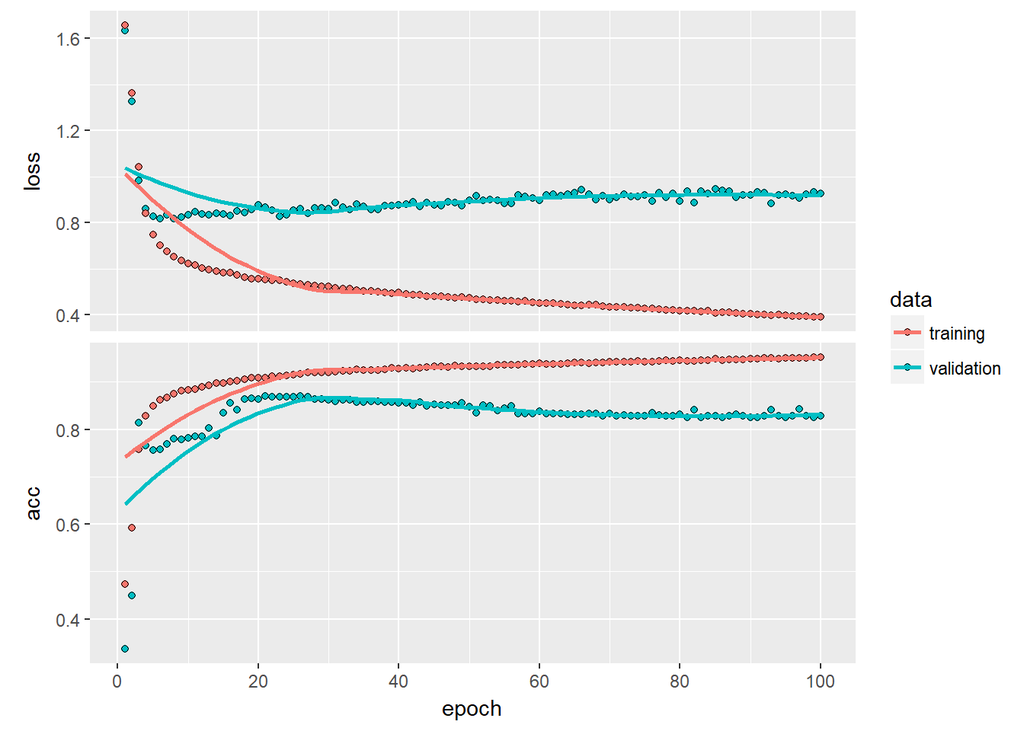

```r
plot(history)
```

#### Evaluate the model

```r
score <- model %>% evaluate(test, testtarget, batch_size = 100)
cat('Test loss:', score[[1]], '\n')
```

```
## Test loss: 0.4861585
```

```r
cat('Test accuracy:', score[[2]], '\n')
```

```
## Test accuracy: 0.9301699
```

#### Prediction & confusion matrix - test data

```r
class.test <- model %>%
  predict_classes(test, batch_size = 100)
# Confusion matrix
table(testtarget,class.test)
```

```
##           class.test
## testtarget    0    1    2    3    4
##          0 1040   85   54    0    0
##          1   50  768   66    0    0
##          2   37    9 1535    4    0
##          3    0    0   28  974    0
##          4    0    0    4    0  172
```

#### Predicted Class Probability

```r
prob.test <- model %>%
  predict_proba(test, batch_size = 100)
```

#### Prediction at grid locations

```r
Class.grid <- model %>%
  predict_classes(grid.df, batch_size = 100)
```

#### Detach keras, tfruns, tftestimators

```r
detach(package:keras, unload=TRUE)
detach(package:tfruns, unload=TRUE)
detach(package:tfestimators, unload=TRUE)
```

#### Change column name

```r
class<-as.data.frame(Class.grid)
new.grid<-cbind(x=grid.xy$x, y=grid.xy$y,Class_ID=class )
names(new.grid)
```

```
## [1] "x"          "y"          "Class.grid"
```

```r
colnames(new.grid)[3]<-"Class_ID"
new.grid.na<-na.omit(new.grid)
```

#### Load landuse ID file

```r
#### Join Class Id Column
ID<-read.csv("Landuse_ID_keras.csv", header=TRUE)
ID
```

```
##   Class_ID   Class           Description
## 1        0 Class_1 Parking/road/pavement
## 2        1 Class_2              Building
## 3        2 Class_3           Tree/bushes
## 4        3 Class_4                 Grass
## 5        4 Class_5                 Water
```

#### Convert to raster

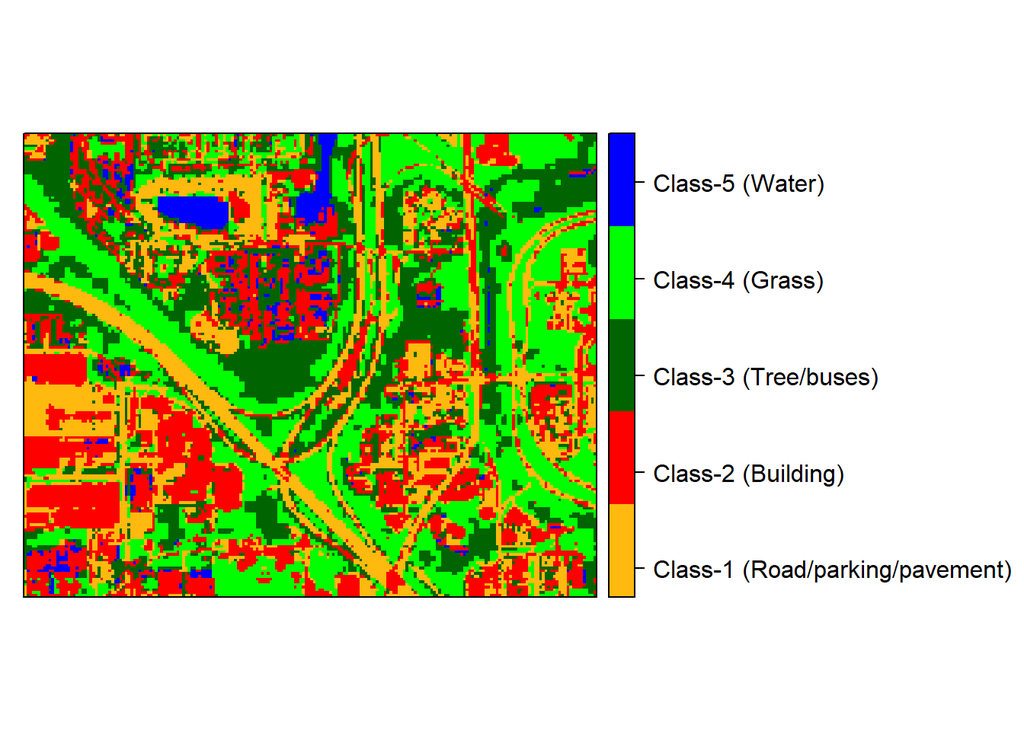

```r
#### Convert to raster
x<-SpatialPointsDataFrame(as.data.frame(new.grid.na)[, c("x", "y")], data = new.grid.na)
r <- rasterFromXYZ(as.data.frame(x)[, c("x", "y", "Class_ID")])

myPalette <- colorRampPalette(c("darkgoldenrod1","red", "darkgreen","green", "blue"))
spplot(r,"Class_ID",
      colorkey = list(space="right",tick.number=1,height=1, width=1.5,
              labels = list(at = seq(0,3.8,length=5),cex=1.0,
              lab = c("Class-1 (Road/parking/pavement)" ,"Class-2 (Building)", "Class-3 (Tree/buses)", "Class-4 (Grass)", "Class-5 (Water)"))),
              col.regions=myPalette,cut=4)
```

```r
writeRaster(r,"predicted_Landuse.tiff","GTiff",overwrite=TRUE)
```

#### Run time

```r
end_time <- Sys.time()
end_time - start_time
```

```
## Time difference of 2.128729 mins
```

### Conclusions

This simple pixel-based satellite image classification algorithm with deep neural network in R with keras able to identify urban objects with high accuracy. It may be use full for landuse classification for urban environment monitoring as well as planning purpose. Also, may use full for agricultural landuse classification.

#### Clean everyrhing

```r
gc()
```

```
##           used  (Mb) gc trigger  (Mb) max used  (Mb)
## Ncells 3205094 171.2    4703850 251.3  4703850 251.3
## Vcells 5988093  45.7   10178327  77.7 10169115  77.6
```